# Week 10 Assignment - Text Mining

### Assignment Description

In Text Mining with R, Chapter 2 looks at Sentiment Analysis. In this assignment, you should start by getting the primary example code from chapter 2 working in an R Markdown document. You should provide a citation to this base code. You’re then asked to extend the code in two ways:

1. Work with a different corpus of your choosing, and
2. Incorporate at least one additional sentiment lexicon (possibly from another R package that you’ve found through research).

As usual, please submit links to both an .Rmd file posted in your GitHub repository and to your code on rpubs.com. You make work on a small team on this assignment.

### Our Datasets

**Sentiment Analysis of US Financial News Headlines Data**

For this assignment I am going to perform a sentiment analysis on US Financial News Headlines data, which were obtained from Kaggle.com at the address below:

https://www.kaggle.com/notlucasp/financial-news-headlines

Context

The datasets consist of 3 sets scraped from CNBC, the Guardian, and Reuters official websites, the headlines in these datasets reflects the overview of the U.S. economy and stock market every day for the past year to 2 years.

Content

- Data scraped from CNBC contains the headlines, last updated date, and the preview text of articles from the end of December 2017 to July 19th, 2020.
- Data scraped from the Guardian Business contains the headlines and last updated date of articles from the end of December 2017 to July 19th, 2020 since the Guardian Business does not offer preview text.
- Data scraped from Reuters contains the headlines, last updated date, and the preview text of articles from the end of March 2018 to July 19th, 2020.

```r
library(tidyverse)
library(tidytext)
library(textdata)    # Needed for loughran lexicon
library(ggplot2)
```

Let’s use the loughran lexicon to perform the sentiment analysis

```r
loughran_sentiments <- get_sentiments("loughran")
```

Let’s take a peak at the sentiments from the “loughran” lexicon

```r
loughran_sentiments
```

```
## # A tibble: 4,150 x 2
##    word         sentiment
##    <chr>        <chr>
##  1 abandon      negative
##  2 abandoned    negative
##  3 abandoning   negative
##  4 abandonment  negative
##  5 abandonments negative
##  6 abandons     negative
##  7 abdicated    negative
##  8 abdicates    negative
##  9 abdicating   negative
## 10 abdication   negative
## # ... with 4,140 more rows
```

### Read the data

```r
cnbc_csv <- read_csv('cnbc_headlines.csv')

head(cnbc_csv, 10)
```

```
## # A tibble: 10 x 3
##    Headlines                       Time          Description
##    <chr>                           <chr>         <chr>
##  1 Jim Cramer: A better way to in~ 7:51  PM ET ~ "\"Mad Money\" host Jim Cramer~
##  2 Cramer's lightning round: I wo~ 7:33  PM ET ~ "\"Mad Money\" host Jim Cramer~
##  3 <NA>                            <NA>           <NA>
##  4 Cramer's week ahead: Big week ~ 7:25  PM ET ~ "\"We'll pay more for the earn~
##  5 IQ Capital CEO Keith Bliss say~ 4:24  PM ET ~ "Keith Bliss, IQ Capital CEO, ~
##  6 Wall Street delivered the 'kin~ 7:36  PM ET ~ "\"Look for the stocks of high~
##  7 Cramer's lightning round: I wo~ 7:23  PM ET ~ "\"Mad Money\" host Jim Cramer~
##  8 Acorns CEO: Parents can turn $~ 8:03  PM ET ~ "Investing $5 per day can comp~
##  9 Dividend cuts may mean rethink~ 8:54  AM ET ~ "Hundreds of companies have cu~
## 10 <NA>                            <NA>           <NA>
```

```r
# Remove all rows where all the column values are blank
cnbc_headlines <- cnbc_csv[rowSums(is.na(cnbc_csv)) != ncol(cnbc_csv), ]

head(cnbc_headlines)
```

```
## # A tibble: 6 x 3
##   Headlines                       Time          Description
##   <chr>                           <chr>         <chr>
## 1 Jim Cramer: A better way to in~ 7:51  PM ET ~ "\"Mad Money\" host Jim Cramer ~
## 2 Cramer's lightning round: I wo~ 7:33  PM ET ~ "\"Mad Money\" host Jim Cramer ~
## 3 Cramer's week ahead: Big week ~ 7:25  PM ET ~ "\"We'll pay more for the earni~
## 4 IQ Capital CEO Keith Bliss say~ 4:24  PM ET ~ "Keith Bliss, IQ Capital CEO, j~
## 5 Wall Street delivered the 'kin~ 7:36  PM ET ~ "\"Look for the stocks of high-~
## 6 Cramer's lightning round: I wo~ 7:23  PM ET ~ "\"Mad Money\" host Jim Cramer ~
```

### Sentiment Analysis with Inner Join

First, we need to take the text of the headlines and convert the text to the tidy format using unnest_tokens(). Let’s also set up a column to keep track of which headline each word comes from.

Add a new columns to the dataframe containing the Headline Date and Month (YYY-MM)

```r
 # Add a new column to the dataframe containing the Headline Date

cnbc_headlines <- cnbc_headlines %>%
  rowwise() %>%
  mutate(Headline_Date = as.Date(sub(".*, ","",Time), format = "%d %B %Y"),
         Headline_YYYYMM = format( as.Date(sub(".*, ","",Time), format = "%d %B %Y"), "%Y-%m")
         )
```

Convert headlines to tidytext format

```r
tidy_cnbc_headlines <- cnbc_headlines %>%
  select(Headline_YYYYMM, Headline_Date, Headlines) %>%
  mutate(linenumber = row_number()) %>%
  unnest_tokens(output = word, input = Headlines, token = "words", format = "text", to_lower = TRUE)
```

First, we find a sentiment score for each word using the “loughran” lexicon and inner_join().

We then use spread() so that we have negative and positive sentiment in separate columns, and lastly calculate a net sentiment (positive - negative).

```r
cnbc_sentiment <- tidy_cnbc_headlines %>%
  inner_join(loughran_sentiments) %>%
  count(Headline_YYYYMM, Headline_Date, sentiment) %>%
  spread(sentiment, n, fill = 0) %>%
  mutate(sentiment = positive - negative)
```

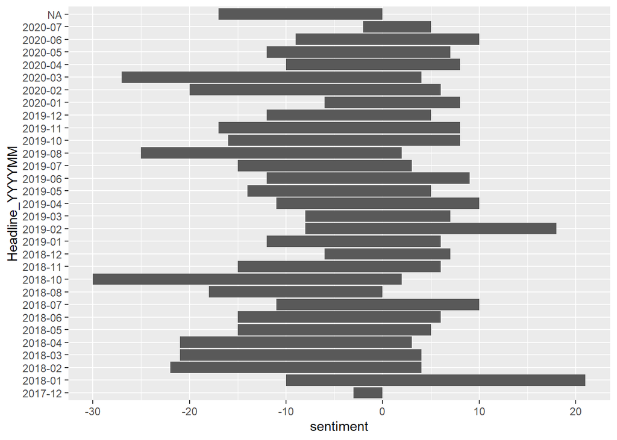

```r
ggplot(cnbc_sentiment, aes(Headline_YYYYMM, sentiment)) +
  geom_col(show.legend = FALSE) +
  #facet_wrap(~Headline_YYYYMM, ncol = 4, scales = "free_x")
  coord_flip()
```

**Most Common Positive and Negative Words**

One advantage of having the data frame with both sentiment and word is that we can analyze word counts that contribute to each sentiment. By implementing count() here with arguments of both word and sentiment, we find out how much each word contributed to each sentiment.

```r
loughran_word_counts <- tidy_cnbc_headlines %>%
  inner_join(get_sentiments("loughran")) %>%
  count(word, sentiment, sort = TRUE) %>%
  ungroup()

loughran_word_counts
```

```
## # A tibble: 431 x 3
##    word        sentiment       n
##    <chr>       <chr>       <int>
##  1 could       uncertainty   167
##  2 good        positive       57
##  3 may         uncertainty    55
##  4 best        positive       46
##  5 recession   negative       35
##  6 opportunity positive       32
##  7 warns       negative       30
##  8 bad         negative       27
##  9 better      positive       27
## 10 wrong       negative       26
## # ... with 421 more rows
```

This can be shown visually, and we can pipe straight into ggplot2, if we like, because of the way we are consistently using tools built for handling tidy data frames

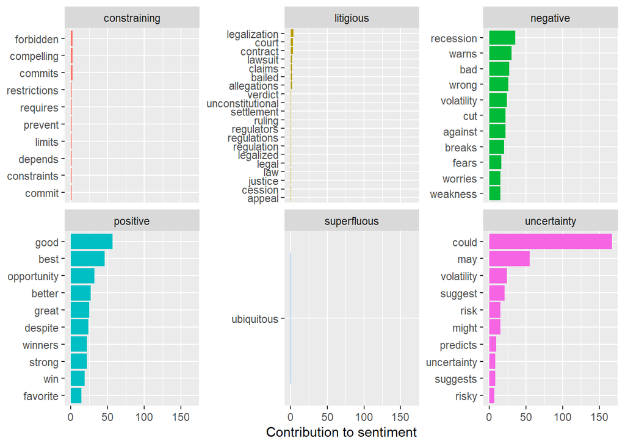

```r
loughran_word_counts %>%
  group_by(sentiment) %>%
  top_n(10) %>%
  ungroup() %>%
  mutate(word = reorder(word, n)) %>%
  ggplot(aes(word, n, fill = sentiment)) +
  geom_col(show.legend = FALSE) +
  facet_wrap(~sentiment, scales = "free_y") +
  labs(y = "Contribution to sentiment",
       x = NULL) +
  coord_flip()
```